# popularidade-javaXpython

laybson

9 de julho de 2018

```r
languages = unique(subset(infoLanguages, select=c("file_extension")))
infoLanguages$languageName = ifelse(infoLanguages$file_extension == 'py', 'Python',
                 ifelse(infoLanguages$file_extension == 'java', 'Java', 'Undefined'))
infoLanguages = infoLanguages %>%
  filter(file_extension %in% c("py", "java"))
```

```r
infoLanguages = infoLanguages %>% mutate(full_date = paste(month_day, the_month, the_year, sep = '-'))
infoLanguages = infoLanguages %>% mutate(week_day = weekdays(as.Date(full_date,'%d-%m-%Y')))
infoLanguages = infoLanguages %>% mutate(is_weekend = weekend(week_day))
```

## Comprativo de popularidade: Java x Python

Com base em uma amostragem de dados advindos do github, mostraremos algumas informações acerca à quantidade de uso das Linguagens Java e Python. As colunas desses dados referem-se à quantidade de usuários que enviaram arquivos de uma determinada extensão em um determinado dia entre 2016 e maio de 2017.

Considerando o total de uso das duas linguagens no período avaliado, temos:

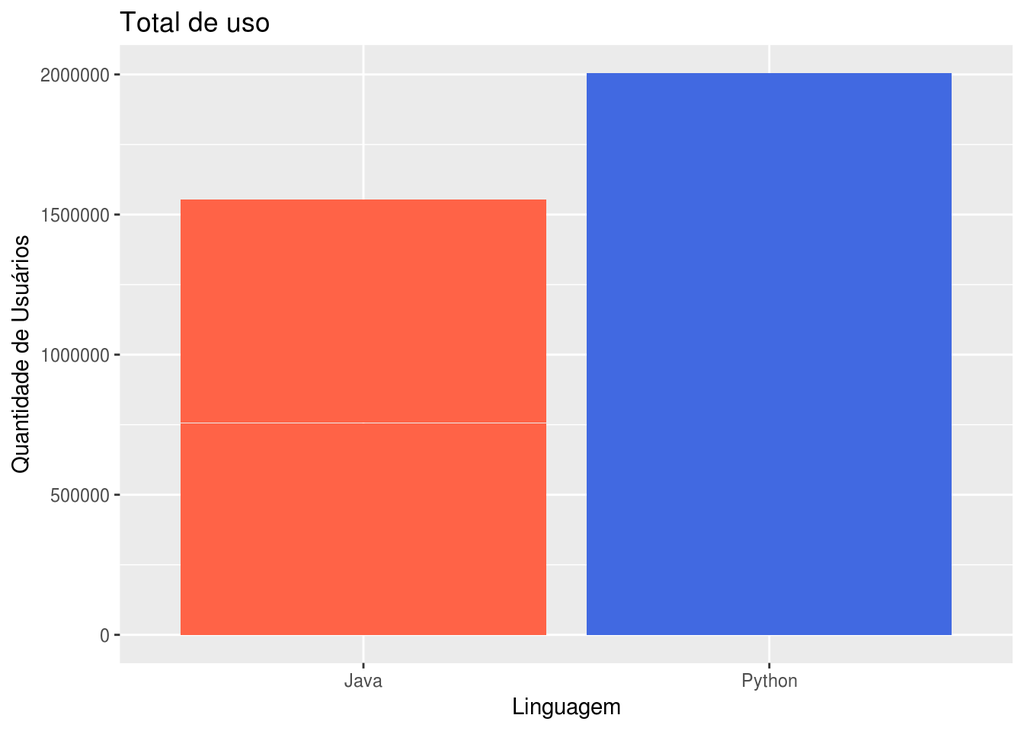

```r
infoLanguages %>%
  group_by(languageName, users) %>%
  summarise(total_users = sum(users)) %>%
  ggplot(aes(x = languageName, y = total_users, fill = languageName)) +
  geom_col() +
  scale_fill_manual( values = c( "Java"="tomato", "Python"="RoyalBlue" ), guide = FALSE ) +
  labs(title = "Total de uso", x = "Linguagem", y = "Quantidade de Usuários")
```

Mostrando por mês temos:

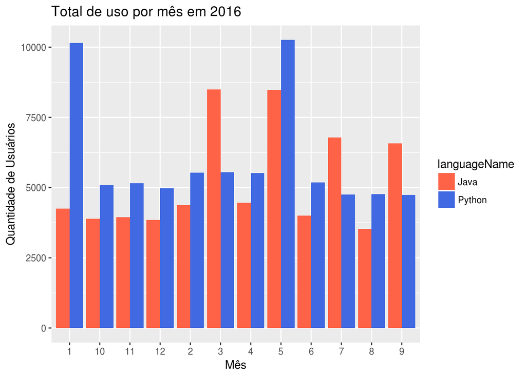

```r
infoLanguages %>%
  group_by(languageName, the_year, the_month, users) %>%
  summarise(total_users = sum(users)) %>%
  filter(the_year %in% c("2016")) %>%
  ggplot(aes(x = as.character(the_month), y = total_users, fill = languageName)) +
  geom_bar(stat='identity', position='dodge') +
  scale_fill_manual( values = c( "Java"="tomato", "Python"="RoyalBlue" )) +
  labs(title = "Total de uso por mês em 2016", x = "Mês", y = "Quantidade de Usuários")
```

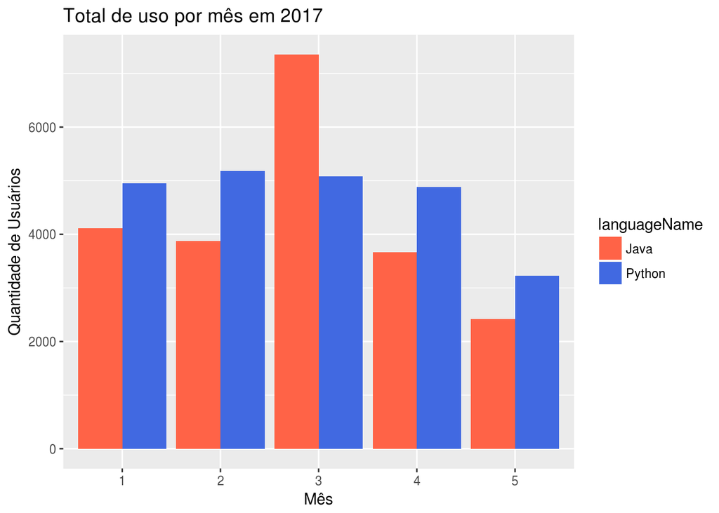

```r
infoLanguages %>%
  group_by(languageName, the_year, the_month, users) %>%
  summarise(total_users = sum(users)) %>%
  filter(the_year %in% c("2017")) %>%
  ggplot(aes(x = as.character(the_month), y = total_users, fill = languageName)) +
  geom_bar(stat='identity', position='dodge') +
  scale_fill_manual( values = c( "Java"="tomato", "Python"="RoyalBlue" )) +
  labs(title = "Total de uso por mês em 2017", x = "Mês", y = "Quantidade de Usuários")
```

Vemos que, em geral, Python vem sendo mais utilizada que Java em nosso conjunto de dados.

## Há uma diferença significativa na popularidade das linguagens durante a semana e durante o fim de semana?

Considerando popularidade como o volume de pessoas utilizando a linguagem em determinado dia, podemos visualizar o seguinte:

### Java

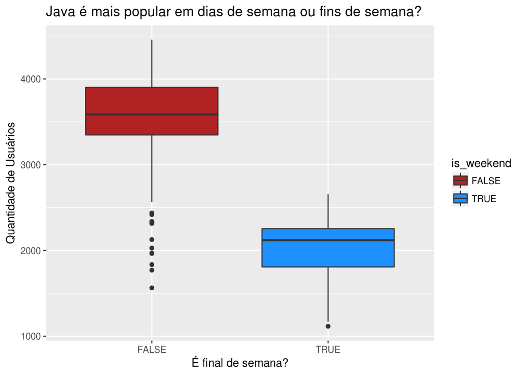

```r
infoLanguages %>%
  filter(languageName == "Java") %>%
  ggplot(aes(x=is_weekend, y=users, group=is_weekend, fill=is_weekend)) +
  geom_boxplot() +
  scale_fill_manual( values = c("TRUE"="DodgerBlue", "FALSE"="FireBrick" )) +
  labs(x="É final de semana?", y="Quantidade de Usuários",title="Java é mais popular em dias de semana ou fins de semana?")
```

O boxplot acima representa a distribuição de número de usuários por dia. A caixa vermelha representa os dias de semana, enquanto a azul representa os fins de semana. É muito claro, que na nossa amostra, Java tende a ser bem mais utilizado nos dias de semana. Isso pode ser observado também no gráfico abaixo:

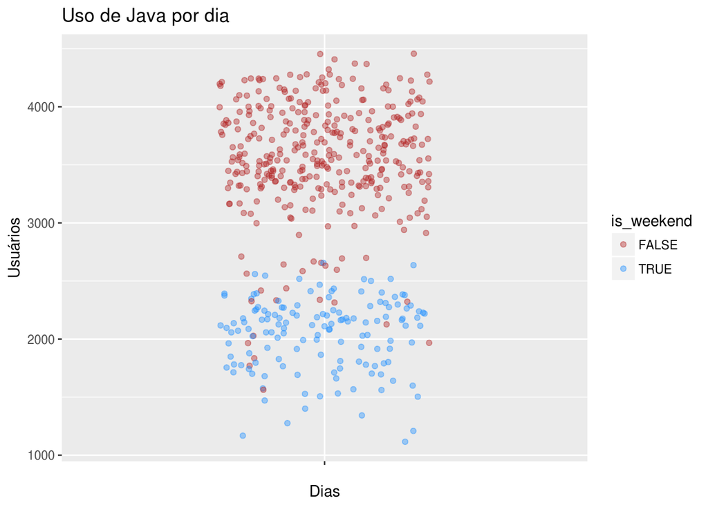

```r
infoLanguages %>%
  filter(languageName == "Java") %>%
  ggplot(aes(x="", y = users, color = is_weekend)) +
  geom_jitter(width = .2, alpha=0.4) +
  scale_color_manual( values = c("TRUE"="DodgerBlue", "FALSE"="FireBrick" )) +
  labs(title = "Uso de Java por dia", x = "Dias", y = "Usuários")
```

Cada ponto representa um dia. Pontos vermelhos são dias da semana, e pontos azuis são fins de semana. O volume de usuários á maior nos dias de semana.

### Python

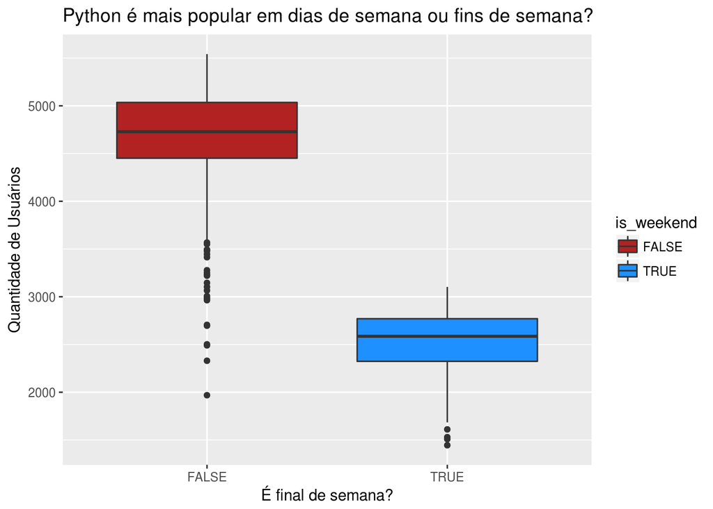

```r
infoLanguages %>%
  filter(languageName == "Python") %>%
  ggplot(aes(x=is_weekend, y=users, group=is_weekend, fill=is_weekend)) +
  geom_boxplot() +
  scale_fill_manual( values = c("TRUE"="DodgerBlue", "FALSE"="FireBrick" )) +
  labs(x="É final de semana?", y="Quantidade de Usuários",title="Python é mais popular em dias de semana ou fins de semana?")
```

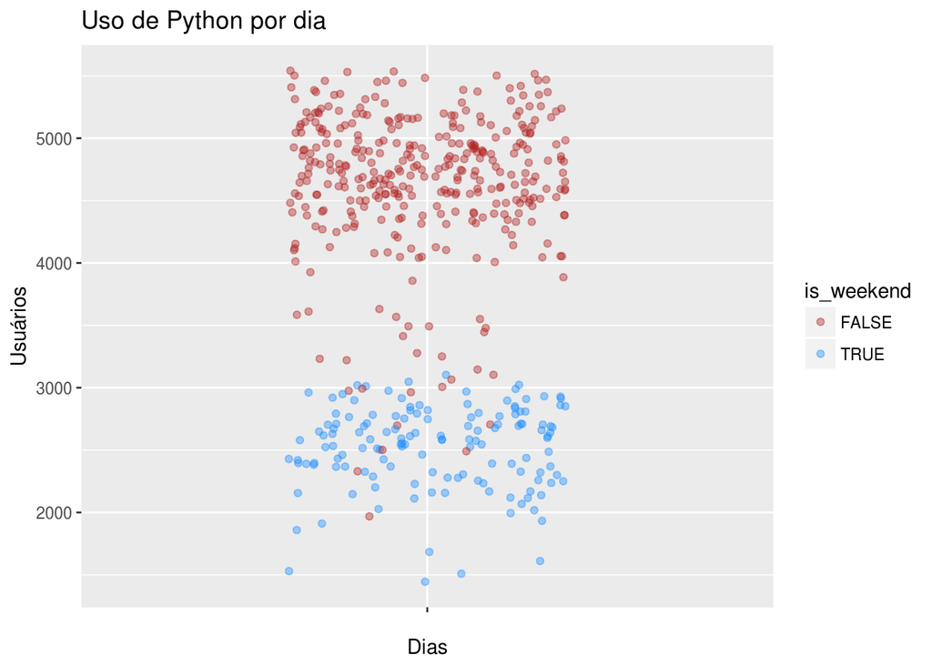

```r
infoLanguages %>%
  filter(languageName == "Python") %>%
  ggplot(aes(x="", y = users, color = is_weekend)) +
  geom_jitter(width = .2, alpha=0.4) +
  scale_color_manual( values = c("TRUE"="DodgerBlue", "FALSE"="FireBrick" )) +
  labs(title = "Uso de Python por dia", x = "Dias", y = "Usuários")
```

O comportamento de Python é muito semelhante ao de Java quanto à diferença de quantidade de uso entre dias de semana e fins de semana na nossa amostragem.

## Existe uma diferença significativa entre a popularidade das duas linguagens nos fins de semana?

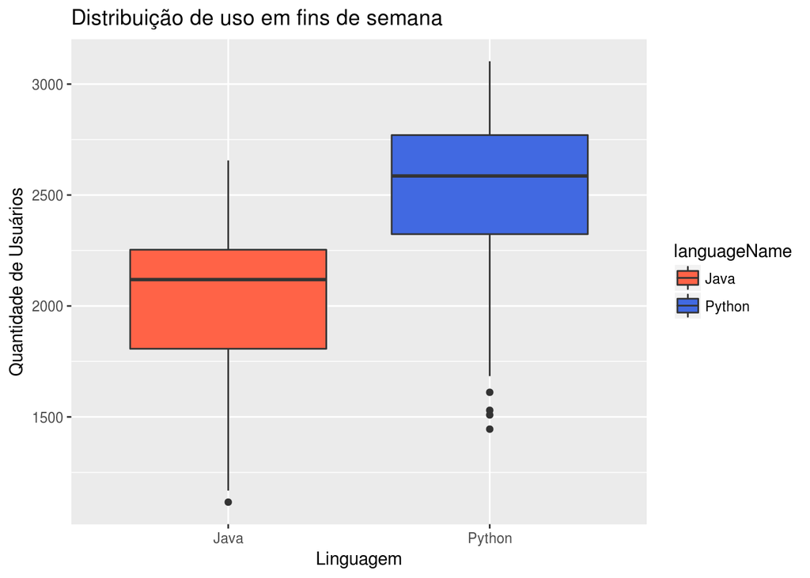

```r
infoLanguages %>%
  filter(is_weekend == TRUE) %>%
  ggplot(aes(x=languageName, y=users, group=languageName, fill=languageName)) +
  geom_boxplot() +
  scale_fill_manual( values = c( "Java"="tomato", "Python"="RoyalBlue" )) +
  labs(x="Linguagem", y="Quantidade de Usuários",title="Distribuição de uso em fins de semana")
```

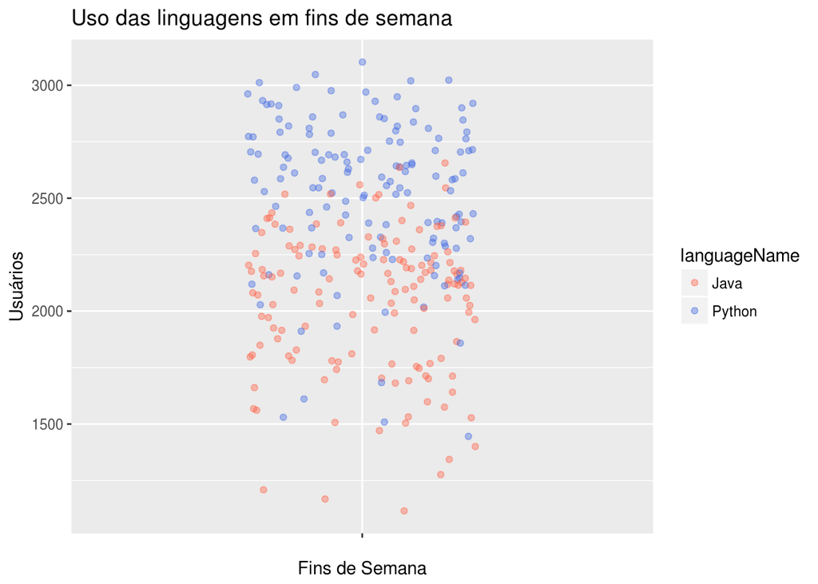

```r
infoLanguages %>%
  filter(is_weekend == TRUE) %>%
  ggplot(aes(x="", y = users, color = languageName)) +
  geom_jitter(width = .2, alpha=0.4) +
  scale_color_manual( values = c( "Java"="tomato", "Python"="RoyalBlue" )) +
  labs(title = "Uso das linguagens em fins de semana", x = "Fins de Semana", y = "Usuários")
```

Vendo as distribuições, é claro que na amostragem, Python tende a ser mais popular que java nos fins de semana.